# Customer Churn Prediction Model

## Logistic Regression Classification

This notebook prepares customer data, builds a machine-learning pipeline, trains a Logistic Regression model, evaluates predictive performance, and interprets the main factors associated with customer churn.

```python
# Import required libraries

from pathlib import Path

import numpy as np
import pandas as pd


# Improve table display

pd.set_option(
    "display.max_columns",
    None
)


# Define the exact dataset path

data_path = Path(
    r"C:\Users\hp15-da\Desktop\معرض عمال\Customer_Churn_Intelligence\data\telco_customer_churn_clean.csv"
)


# Load the cleaned dataset

df = pd.read_csv(
    data_path
)


print(
    "Dataset loaded successfully."
)

print(
    f"Dataset shape: {df.shape}"
)
```

```
Dataset loaded successfully.
Dataset shape: (7043, 33)
```

```python
# Preserve customer IDs for future prediction outputs

customer_ids = (

    df["customer_id"]

    .copy()

)


# Define columns excluded from model training

columns_to_exclude = [

    # Customer identifier

    "customer_id",


    # Constant or non-predictive fields

    "customer_count",

    "country",

    "state",


    # High-cardinality geographic fields

    "city",

    "zip_code",

    "lat_long",

    "latitude",

    "longitude",


    # Target or data-leakage fields

    "churn_label",

    "churn_value",

    "churn_score",

    "churn_reason"

]


# Create model features

X = (

    df

    .drop(

        columns=columns_to_exclude

    )

    .copy()

)


# Create the target variable

y = (

    df["churn_value"]

    .astype(int)

    .copy()

)


print(

    f"Feature matrix shape: {X.shape}"

)

print(

    f"Target vector shape: {y.shape}"

)
```

```
Feature matrix shape: (7043, 20)
Target vector shape: (7043,)
```

```python
# Review the target-class distribution

target_distribution = (

    y

    .value_counts()

    .sort_index()

    .rename_axis(
        "churn_value"
    )

    .reset_index(
        name="customer_count"
    )

)


target_distribution[
    "percentage"
] = (

    target_distribution[
        "customer_count"
    ]

    / len(y)

    * 100

)


target_distribution[
    "percentage"
] = (

    target_distribution[
        "percentage"
    ]

    .round(2)

)


target_distribution
```

|  | churn_value | customer_count | percentage |
| --- | --- | --- | --- |
| 0 | 0 | 5174 | 73.46 |
| 1 | 1 | 1869 | 26.54 |

## 1. Train–Test Split and Data Preprocessing

The dataset is divided into training and testing subsets using stratified sampling to preserve the original churn distribution.

Numerical features are standardized, while categorical features are converted into machine-readable variables using one-hot encoding.

```python
# Import preprocessing and model-selection tools

from sklearn.compose import ColumnTransformer

from sklearn.impute import SimpleImputer

from sklearn.model_selection import train_test_split

from sklearn.pipeline import Pipeline

from sklearn.preprocessing import (
    OneHotEncoder,
    StandardScaler
)


print(
    "Preprocessing tools imported successfully."
)
```

```
Preprocessing tools imported successfully.
```

```python
# Define numerical model features

numerical_features = [

    "tenure_months",

    "monthly_charges",

    "total_charges",

    "cltv"

]


# Identify the remaining categorical features

categorical_features = [

    column

    for column in X.columns

    if column not in numerical_features

]


print(
    f"Number of numerical features: "
    f"{len(numerical_features)}"
)


print(
    f"Number of categorical features: "
    f"{len(categorical_features)}"
)


print(
    "\nNumerical features:"
)


print(
    numerical_features
)


print(
    "\nCategorical features:"
)


print(
    categorical_features
)
```

```
Number of numerical features: 4
Number of categorical features: 16

Numerical features:
['tenure_months', 'monthly_charges', 'total_charges', 'cltv']

Categorical features:
['gender', 'senior_citizen', 'partner', 'dependents', 'phone_service', 'multiple_lines', 'internet_service', 'online_security', 'online_backup', 'device_protection', 'tech_support', 'streaming_tv', 'streaming_movies', 'contract', 'paperless_billing', 'payment_method']
```

```python
# Split the dataset into training and testing subsets

X_train, X_test, y_train, y_test = (

    train_test_split(

        X,

        y,

        test_size=0.20,

        random_state=42,

        stratify=y

    )

)


print(
    f"X_train shape: {X_train.shape}"
)


print(
    f"X_test shape: {X_test.shape}"
)


print(
    f"y_train shape: {y_train.shape}"
)


print(
    f"y_test shape: {y_test.shape}"
)
```

```
X_train shape: (5634, 20)
X_test shape: (1409, 20)
y_train shape: (5634,)
y_test shape: (1409,)
```

```python
# Confirm churn distribution across train and test sets

split_distribution = pd.DataFrame(

    {

        "Full Dataset": (

            y.value_counts(

                normalize=True

            )

            .sort_index()

            * 100

        ),


        "Training Set": (

            y_train.value_counts(

                normalize=True

            )

            .sort_index()

            * 100

        ),


        "Testing Set": (

            y_test.value_counts(

                normalize=True

            )

            .sort_index()

            * 100

        )

    }

)


split_distribution.index = [

    "Retained (0)",

    "Churned (1)"

]


split_distribution = (

    split_distribution

    .round(2)

)


split_distribution
```

|  | Full Dataset | Training Set | Testing Set |
| --- | --- | --- | --- |
| Retained (0) | 73.46 | 73.46 | 73.46 |
| Churned (1) | 26.54 | 26.54 | 26.54 |

```python
# Build the numerical preprocessing pipeline

numerical_transformer = Pipeline(

    steps=[

        (

            "imputer",

            SimpleImputer(

                strategy="median"

            )

        ),

        (

            "scaler",

            StandardScaler()

        )

    ]

)


# Build the categorical preprocessing pipeline

categorical_transformer = Pipeline(

    steps=[

        (

            "imputer",

            SimpleImputer(

                strategy="most_frequent"

            )

        ),

        (

            "onehot",

            OneHotEncoder(

                handle_unknown="ignore",

                drop="if_binary"

            )

        )

    ]

)


# Combine numerical and categorical preprocessing

preprocessor = ColumnTransformer(

    transformers=[

        (

            "numerical",

            numerical_transformer,

            numerical_features

        ),

        (

            "categorical",

            categorical_transformer,

            categorical_features

        )

    ]

)


print(
    "Preprocessing pipeline created successfully."
)
```

```
Preprocessing pipeline created successfully.
```

## 2. Logistic Regression Model Training

A Logistic Regression classifier is trained using a unified machine-learning pipeline that combines preprocessing and classification.

Class weighting is applied to reduce the effect of class imbalance and improve the model's ability to identify customers at risk of churn.

```python
# Import the Logistic Regression classifier

from sklearn.linear_model import LogisticRegression


print(
    "Logistic Regression imported successfully."
)
```

```
Logistic Regression imported successfully.
```

```python
# Build the complete machine-learning pipeline

logistic_model = Pipeline(

    steps=[

        (

            "preprocessor",

            preprocessor

        ),

        (

            "classifier",

            LogisticRegression(

                solver="liblinear",

                max_iter=1000,

                class_weight="balanced",

                random_state=42

            )

        )

    ]

)


print(
    "Logistic Regression pipeline created successfully."
)
```

```
Logistic Regression pipeline created successfully.
```

```python
class_weight="balanced"
```

```python
# Train the Logistic Regression model

logistic_model.fit(

    X_train,

    y_train

)


print(
    "Logistic Regression model trained successfully."
)
```

```
Logistic Regression model trained successfully.
```

```python
# Generate class predictions for the testing data

y_pred = (

    logistic_model

    .predict(

        X_test

    )

)


# Generate churn probabilities

y_pred_probability = (

    logistic_model

    .predict_proba(

        X_test

    )

    [:, 1]

)


print(
    "Testing predictions generated successfully."
)


print(

    f"Number of predictions: "

    f"{len(y_pred):,}"

)


print(

    f"Number of churn probabilities: "

    f"{len(y_pred_probability):,}"

)
```

```
Testing predictions generated successfully.
Number of predictions: 1,409
Number of churn probabilities: 1,409
```

```python
# Preview the first 10 model predictions

prediction_preview = pd.DataFrame(

    {

        "Actual Churn": (

            y_test

            .reset_index(

                drop=True

            )

        ),

        "Predicted Churn": (

            y_pred

        ),

        "Churn Probability": (

            y_pred_probability

        )

    }

)


prediction_preview[

    "Churn Probability"

] = (

    prediction_preview[

        "Churn Probability"

    ]

    .round(4)

)


prediction_preview.head(10)
```

|  | Actual Churn | Predicted Churn | Churn Probability |
| --- | --- | --- | --- |
| 0 | 0 | 1 | 0.5539 |
| 1 | 0 | 1 | 0.7191 |
| 2 | 0 | 0 | 0.0108 |
| 3 | 0 | 0 | 0.0391 |
| 4 | 0 | 0 | 0.4448 |
| 5 | 0 | 1 | 0.8063 |
| 6 | 0 | 1 | 0.5958 |
| 7 | 0 | 0 | 0.0524 |
| 8 | 0 | 0 | 0.0035 |
| 9 | 1 | 1 | 0.6587 |

## 3. Model Performance Evaluation

The trained Logistic Regression model is evaluated using multiple classification metrics.

Because customer churn is an imbalanced classification problem, model performance is assessed using precision, recall, F1-score, balanced accuracy, ROC-AUC, and the confusion matrix rather than relying on accuracy alone.

```python
# Import model-evaluation tools

import matplotlib.pyplot as plt

from sklearn.metrics import (
    accuracy_score,
    balanced_accuracy_score,
    classification_report,
    confusion_matrix,
    ConfusionMatrixDisplay,
    f1_score,
    precision_score,
    recall_score,
    roc_auc_score,
    roc_curve
)


print(
    "Model-evaluation tools imported successfully."
)
```

```
Model-evaluation tools imported successfully.
```

```python
# Calculate classification-performance metrics

accuracy = accuracy_score(
    y_test,
    y_pred
)


balanced_accuracy = balanced_accuracy_score(
    y_test,
    y_pred
)


precision = precision_score(
    y_test,
    y_pred,
    zero_division=0
)


recall = recall_score(
    y_test,
    y_pred,
    zero_division=0
)


f1 = f1_score(
    y_test,
    y_pred,
    zero_division=0
)


roc_auc = roc_auc_score(
    y_test,
    y_pred_probability
)


# Create a model-performance summary

model_metrics = pd.DataFrame(
    {
        "Metric": [
            "Accuracy",
            "Balanced Accuracy",
            "Precision",
            "Recall",
            "F1-Score",
            "ROC-AUC"
        ],

        "Score": [
            accuracy,
            balanced_accuracy,
            precision,
            recall,
            f1,
            roc_auc
        ]
    }
)


model_metrics[
    "Score"
] = (

    model_metrics[
        "Score"
    ]

    .round(4)

)


model_metrics
```

|  | Metric | Score |
| --- | --- | --- |
| 0 | Accuracy | 0.7445 |
| 1 | Balanced Accuracy | 0.7603 |
| 2 | Precision | 0.5121 |
| 3 | Recall | 0.7941 |
| 4 | F1-Score | 0.6226 |
| 5 | ROC-AUC | 0.8569 |

```python
# Display the complete classification report

classification_results = classification_report(

    y_test,

    y_pred,

    target_names=[

        "Retained",

        "Churned"

    ],

    zero_division=0

)


print(
    classification_results
)
```

```
              precision    recall  f1-score   support

    Retained       0.91      0.73      0.81      1035
     Churned       0.51      0.79      0.62       374

    accuracy                           0.74      1409
   macro avg       0.71      0.76      0.71      1409
weighted avg       0.80      0.74      0.76      1409
```

```python
# Calculate the confusion matrix

confusion_matrix_values = confusion_matrix(

    y_test,

    y_pred

)


# Extract individual classification outcomes

true_negatives, false_positives, false_negatives, true_positives = (

    confusion_matrix_values.ravel()

)


confusion_summary = pd.DataFrame(

    {

        "Outcome": [

            "True Negatives",

            "False Positives",

            "False Negatives",

            "True Positives"

        ],

        "Customers": [

            true_negatives,

            false_positives,

            false_negatives,

            true_positives

        ]

    }

)


confusion_summary
```

|  | Outcome | Customers |
| --- | --- | --- |
| 0 | True Negatives | 752 |
| 1 | False Positives | 283 |
| 2 | False Negatives | 77 |
| 3 | True Positives | 297 |

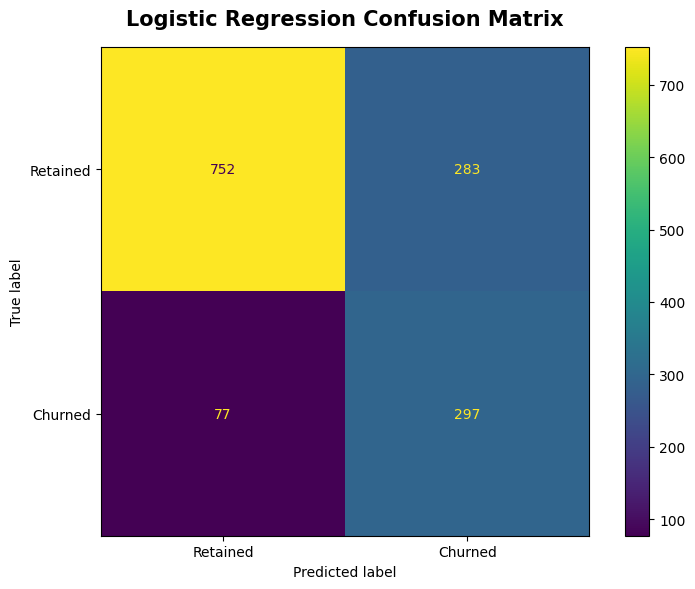

```
Chart saved successfully:
C:\Users\hp15-da\Desktop\معرض عمال\Customer_Churn_Intelligence\images\12_confusion_matrix.png
```

```python
# Define the project images folder

project_path = Path(

    r"C:\Users\hp15-da\Desktop\معرض عمال\Customer_Churn_Intelligence"

)


images_path = (

    project_path

    / "images"

)


images_path.mkdir(

    parents=True,

    exist_ok=True

)


# Create the confusion-matrix visualization

fig, ax = plt.subplots(

    figsize=(8, 6)

)


display = ConfusionMatrixDisplay(

    confusion_matrix=(

        confusion_matrix_values

    ),

    display_labels=[

        "Retained",

        "Churned"

    ]

)


display.plot(

    ax=ax,

    values_format="d"

)


ax.set_title(

    "Logistic Regression Confusion Matrix",

    fontsize=15,

    fontweight="bold",

    pad=16

)


plt.tight_layout()


# Save the chart

confusion_matrix_path = (

    images_path

    / "12_confusion_matrix.png"

)


plt.savefig(

    confusion_matrix_path,

    dpi=300,

    bbox_inches="tight"

)


plt.show()


print(

    f"Chart saved successfully:\n"

    f"{confusion_matrix_path}"

)
```

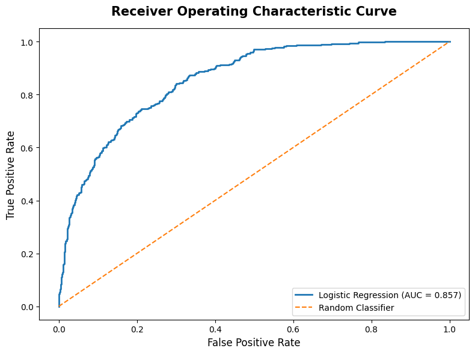

```
Chart saved successfully:
C:\Users\hp15-da\Desktop\معرض عمال\Customer_Churn_Intelligence\images\13_roc_curve.png
```

```python
# Calculate the ROC curve

false_positive_rate, true_positive_rate, thresholds = (

    roc_curve(

        y_test,

        y_pred_probability

    )

)


# Create the ROC-curve visualization

fig, ax = plt.subplots(

    figsize=(8, 6)

)


ax.plot(

    false_positive_rate,

    true_positive_rate,

    linewidth=2,

    label=(

        f"Logistic Regression "

        f"(AUC = {roc_auc:.3f})"

    )

)


ax.plot(

    [0, 1],

    [0, 1],

    linestyle="--",

    label="Random Classifier"

)


ax.set_title(

    "Receiver Operating Characteristic Curve",

    fontsize=15,

    fontweight="bold",

    pad=16

)


ax.set_xlabel(

    "False Positive Rate",

    fontsize=12

)


ax.set_ylabel(

    "True Positive Rate",

    fontsize=12

)


ax.legend(

    loc="lower right"

)


plt.tight_layout()


# Save the chart

roc_curve_path = (

    images_path

    / "13_roc_curve.png"

)


plt.savefig(

    roc_curve_path,

    dpi=300,

    bbox_inches="tight"

)


plt.show()


print(

    f"Chart saved successfully:\n"

    f"{roc_curve_path}"

)
```

## 4. Model Interpretation

The Logistic Regression coefficients are examined to identify the customer characteristics most strongly associated with higher or lower predicted churn risk.

Positive coefficients are associated with increased predicted churn probability, while negative coefficients are associated with reduced predicted churn probability.

These coefficients describe model associations and should not be interpreted as proof of causation.

```python
# Extract the fitted preprocessing pipeline

fitted_preprocessor = (

    logistic_model

    .named_steps[
        "preprocessor"
    ]

)


# Extract transformed feature names

feature_names = (

    fitted_preprocessor

    .get_feature_names_out()

)


# Extract Logistic Regression coefficients

model_coefficients = (

    logistic_model

    .named_steps[
        "classifier"
    ]

    .coef_[0]

)


print(
    f"Number of transformed features: "
    f"{len(feature_names)}"
)


print(
    f"Number of model coefficients: "
    f"{len(model_coefficients)}"
)
```

```
Number of transformed features: 41
Number of model coefficients: 41
```

```python
# Create a feature-coefficient table

feature_effects = pd.DataFrame(

    {

        "feature": (

            feature_names

        ),

        "coefficient": (

            model_coefficients

        )

    }

)


# Remove preprocessing prefixes

feature_effects[
    "feature"
] = (

    feature_effects[
        "feature"
    ]

    .str.replace(

        "numerical__",

        "",

        regex=False

    )

    .str.replace(

        "categorical__",

        "",

        regex=False

    )

)


# Calculate odds ratios

feature_effects[

    "odds_ratio"

] = np.exp(

    feature_effects[

        "coefficient"

    ]

)


# Add coefficient direction

feature_effects[

    "association"

] = np.where(

    feature_effects[

        "coefficient"

    ] > 0,

    "Higher Predicted Churn",

    "Lower Predicted Churn"

)


# Calculate absolute coefficient strength

feature_effects[

    "absolute_coefficient"

] = (

    feature_effects[

        "coefficient"

    ]

    .abs()

)


feature_effects = (

    feature_effects

    .sort_values(

        "absolute_coefficient",

        ascending=False

    )

    .reset_index(

        drop=True

    )

)


feature_effects.head(20)
```

|  | feature | coefficient | odds_ratio | association | absolute_coefficient |
| --- | --- | --- | --- | --- | --- |
| 0 | dependents_Yes | -1.627638 | 0.196393 | Lower Predicted Churn | 1.627638 |
| 1 | tenure_months | -1.233910 | 0.291152 | Lower Predicted Churn | 1.233910 |
| 2 | contract_Two year | -0.789109 | 0.454249 | Lower Predicted Churn | 0.789109 |
| 3 | contract_Month-to-month | 0.633976 | 1.885091 | Higher Predicted Churn | 0.633976 |
| 4 | total_charges | 0.540582 | 1.717006 | Higher Predicted Churn | 0.540582 |
| 5 | internet_service_DSL | -0.540542 | 0.582433 | Lower Predicted Churn | 0.540542 |
| 6 | monthly_charges | -0.533548 | 0.586520 | Lower Predicted Churn | 0.533548 |
| 7 | internet_service_Fiber optic | 0.529468 | 1.698029 | Higher Predicted Churn | 0.529468 |
| 8 | paperless_billing_Yes | 0.295943 | 1.344393 | Higher Predicted Churn | 0.295943 |
| 9 | tech_support_No internet service | -0.267520 | 0.765275 | Lower Predicted Churn | 0.267520 |
| 10 | online_backup_No internet service | -0.267520 | 0.765275 | Lower Predicted Churn | 0.267520 |
| 11 | streaming_tv_No internet service | -0.267520 | 0.765275 | Lower Predicted Churn | 0.267520 |
| 12 | streaming_movies_No internet service | -0.267520 | 0.765275 | Lower Predicted Churn | 0.267520 |
| 13 | internet_service_No | -0.267520 | 0.765275 | Lower Predicted Churn | 0.267520 |
| 14 | device_protection_No internet service | -0.267520 | 0.765275 | Lower Predicted Churn | 0.267520 |
| 15 | online_security_No internet service | -0.267520 | 0.765275 | Lower Predicted Churn | 0.267520 |
| 16 | partner_Yes | 0.262598 | 1.300304 | Higher Predicted Churn | 0.262598 |
| 17 | multiple_lines_No | -0.225142 | 0.798403 | Lower Predicted Churn | 0.225142 |
| 18 | streaming_movies_No | -0.203584 | 0.815801 | Lower Predicted Churn | 0.203584 |
| 19 | streaming_movies_Yes | 0.192511 | 1.212290 | Higher Predicted Churn | 0.192511 |

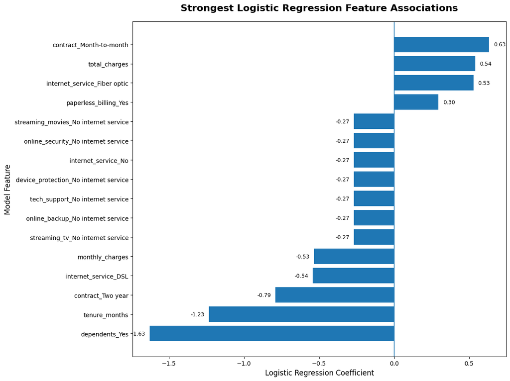

```
Chart saved successfully:
C:\Users\hp15-da\Desktop\معرض عمال\Customer_Churn_Intelligence\images\14_logistic_regression_feature_effects.png
```

```python
# Select the strongest model associations

top_feature_effects = (

    feature_effects

    .head(16)

    .sort_values(

        "coefficient",

        ascending=True

    )

)


# Create the coefficient chart

fig, ax = plt.subplots(

    figsize=(12, 9)

)


bars = ax.barh(

    top_feature_effects[

        "feature"

    ],

    top_feature_effects[

        "coefficient"

    ]

)


# Add a reference line at zero

ax.axvline(

    x=0,

    linewidth=1.2

)


# Add coefficient labels

for bar, coefficient in zip(

    bars,

    top_feature_effects[

        "coefficient"

    ]

):

    label_position = (

        coefficient + 0.03

        if coefficient >= 0

        else coefficient - 0.03

    )


    alignment = (

        "left"

        if coefficient >= 0

        else "right"

    )


    ax.text(

        label_position,

        bar.get_y()

        + bar.get_height() / 2,

        f"{coefficient:.2f}",

        va="center",

        ha=alignment,

        fontsize=9

    )


# Format the chart

ax.set_title(

    "Strongest Logistic Regression Feature Associations",

    fontsize=16,

    fontweight="bold",

    pad=18

)


ax.set_xlabel(

    "Logistic Regression Coefficient",

    fontsize=12

)


ax.set_ylabel(

    "Model Feature",

    fontsize=12

)


plt.tight_layout()


# Save the chart

feature_effects_chart_path = (

    images_path

    / "14_logistic_regression_feature_effects.png"

)


plt.savefig(

    feature_effects_chart_path,

    dpi=300,

    bbox_inches="tight"

)


plt.show()


print(

    f"Chart saved successfully:\n"

    f"{feature_effects_chart_path}"

)
```

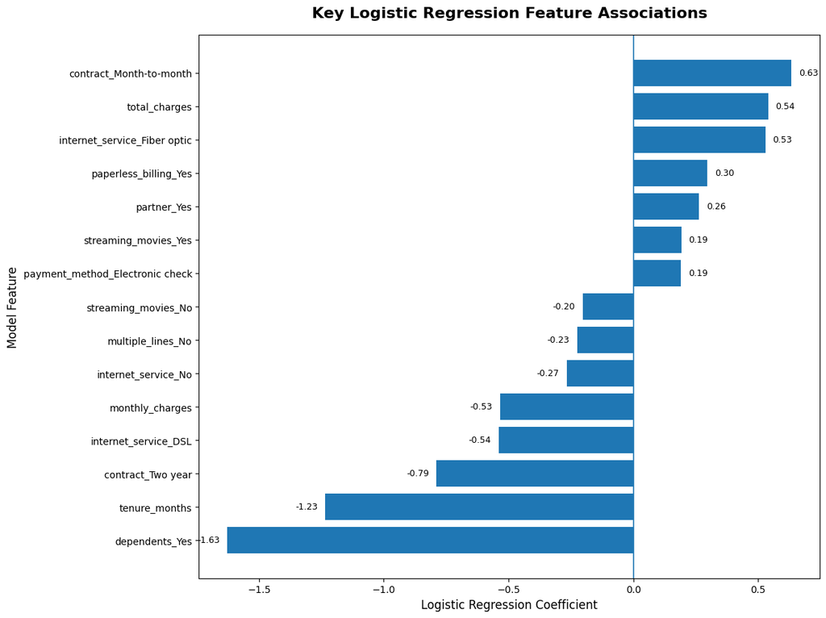

```
Chart saved successfully:
C:\Users\hp15-da\Desktop\معرض عمال\Customer_Churn_Intelligence\images\15_key_logistic_regression_features.png
```

```python
# Remove repeated "No internet service" indicators
# from the interpretation chart only

clean_feature_effects = (

    feature_effects.loc[

        ~feature_effects[
            "feature"
        ]

        .str.contains(

            "No internet service",

            case=False,

            na=False

        )

    ]

    .copy()

)


# Select the strongest non-redundant associations

top_clean_feature_effects = (

    clean_feature_effects

    .head(15)

    .sort_values(

        "coefficient",

        ascending=True

    )

)


# Create the cleaner interpretation chart

fig, ax = plt.subplots(

    figsize=(12, 9)

)


bars = ax.barh(

    top_clean_feature_effects[
        "feature"
    ],

    top_clean_feature_effects[
        "coefficient"
    ]

)


ax.axvline(

    x=0,

    linewidth=1.2

)


# Add coefficient labels

for bar, coefficient in zip(

    bars,

    top_clean_feature_effects[
        "coefficient"
    ]

):

    label_position = (

        coefficient + 0.03

        if coefficient >= 0

        else coefficient - 0.03

    )


    alignment = (

        "left"

        if coefficient >= 0

        else "right"

    )


    ax.text(

        label_position,

        bar.get_y()

        + bar.get_height() / 2,

        f"{coefficient:.2f}",

        va="center",

        ha=alignment,

        fontsize=9

    )


ax.set_title(

    "Key Logistic Regression Feature Associations",

    fontsize=16,

    fontweight="bold",

    pad=18

)


ax.set_xlabel(

    "Logistic Regression Coefficient",

    fontsize=12

)


ax.set_ylabel(

    "Model Feature",

    fontsize=12

)


plt.tight_layout()


# Save the cleaner chart

clean_feature_chart_path = (

    images_path

    / "15_key_logistic_regression_features.png"

)


plt.savefig(

    clean_feature_chart_path,

    dpi=300,

    bbox_inches="tight"

)


plt.show()


print(

    f"Chart saved successfully:\n"

    f"{clean_feature_chart_path}"

)
```

## 5. Model Interpretation and Business Recommendations

### Model Performance Summary

The Logistic Regression model was evaluated using an independent testing dataset containing 1,409 customers.

The model achieved the following results:

- **Accuracy:** 74.45%
- **Balanced Accuracy:** 76.03%
- **Precision for churn:** 51.21%
- **Recall for churn:** 79.41%
- **F1-Score:** 62.26%
- **ROC-AUC:** 85.70%

The confusion matrix showed that the model:

- Correctly identified **752 retained customers**.
- Correctly identified **297 churned customers**.
- Classified **283 retained customers** as being at risk of churn.
- Missed **77 customers** who actually churned.

The model correctly detected approximately **79% of customers who actually churned**.

This relatively high recall is valuable in a customer-retention setting because failing to identify a customer at genuine risk may result in a lost opportunity to prevent customer loss.

The model also produced a considerable number of false-positive predictions. These customers did not actually churn but were classified as being at risk.

The appropriate prediction threshold should therefore depend on:

- The cost of customer-retention interventions
- The value of retaining a customer
- Available retention resources
- The acceptable balance between identifying more at-risk customers and reducing unnecessary interventions

The ROC-AUC score of **0.857** indicates that the model demonstrated strong ability to distinguish between customers with higher and lower churn risk.

### Key Model Associations

The final Logistic Regression coefficient analysis identified several customer characteristics associated with higher or lower predicted churn risk after accounting for the other variables included in the model.

Positive coefficients indicate an association with higher predicted churn probability.

Negative coefficients indicate an association with lower predicted churn probability.

These relationships represent statistical associations and should not be interpreted as evidence of direct causation.

### Factors Associated with Higher Predicted Churn

The strongest positive model associations included:

#### Month-to-Month Contracts

Month-to-month contracts showed the strongest positive contract-related association with predicted churn.

This result was consistent with the exploratory analysis, where month-to-month customers recorded a churn rate of **42.71%**.

Customers with flexible monthly contracts may have fewer barriers to switching providers and may therefore require stronger retention efforts.

#### Fiber Optic Internet Service

Fiber optic service was associated with higher predicted churn after accounting for the other model variables.

The exploratory analysis also showed that fiber optic customers recorded a churn rate of **41.89%**.

This result does not indicate that fiber optic technology causes churn. Possible contributing factors may include:

- Higher monthly charges
- Service expectations
- Reliability concerns
- Competitive offers
- Differences in customer profiles

#### Paperless Billing

Paperless billing showed a moderate positive association with predicted churn.

However, this variable should be interpreted carefully because customers using paperless billing may also differ in contract type, internet service, payment method, and monthly charges.

#### Electronic Check Payment

Electronic check payment showed a positive association with predicted churn.

This result was consistent with the exploratory analysis, where electronic check customers recorded the highest payment-method churn rate at **45.29%**.

Electronic check users may represent an important customer group for targeted payment-conversion programs.

#### Total Charges

Total charges showed a positive conditional coefficient after accounting for customer tenure, monthly charges, contract type, services, and other model variables.

This result should not be interpreted independently because total charges are strongly related to customer tenure and monthly spending.

### Factors Associated with Lower Predicted Churn

The strongest negative model associations included:

#### Having Dependents

Having dependents showed the largest negative model coefficient.

Customers with dependents also recorded substantially lower churn during the exploratory analysis.

This relationship may reflect greater household stability, longer customer relationships, or differences in contract and service usage.

#### Longer Customer Tenure

Longer customer tenure showed a strong negative association with predicted churn.

This result was consistent with the exploratory analysis:

- Customers within their first 0–6 months recorded a churn rate of **52.94%**.
- Customers with more than 49 months of tenure recorded a churn rate of only **9.51%**.

Customer tenure appears to be one of the strongest indicators of customer stability.

#### Two-Year Contracts

Two-year contracts showed a strong negative association with predicted churn.

The exploratory analysis showed that two-year customers recorded a churn rate of only **2.83%**.

Long-term contractual commitment was therefore associated with stronger customer retention.

#### DSL Internet Service

DSL service showed a lower predicted churn association compared with other modeled internet-service categories.

The exploratory analysis also showed a lower churn rate among DSL customers than fiber optic customers.

#### No Internet Service

Customers without internet service showed a lower predicted churn association within this dataset.

This relationship may reflect lower service complexity, lower monthly charges, or differences in customer needs.

### Interpretation Considerations

Logistic Regression coefficients represent conditional associations while holding the other modeled variables constant.

They should not be interpreted as evidence that a specific feature directly causes customer churn.

The numerical variables were standardized before model training.

Therefore, the coefficients and odds ratios of numerical features represent the estimated effect associated with approximately a one-standard-deviation increase rather than a one-unit increase.

Monthly charges, total charges, tenure, contract type, and internet-service type are strongly related.

Their coefficients should therefore be interpreted jointly rather than used independently to make direct pricing conclusions.

The model produced:

- A negative coefficient for monthly charges
- A positive coefficient for total charges

This does not mean that higher monthly charges directly reduce churn.

These coefficients reflect conditional relationships after accounting for customer tenure, contract type, service usage, and the other variables included in the model.

Partner status showed a positive model coefficient even though customers with partners recorded a lower churn rate during the descriptive analysis.

This difference may occur because the multivariable model estimates the relationship of partner status after accounting for:

- Customer tenure
- Dependents
- Contract type
- Services
- Payment behavior
- Other customer characteristics

Repeated service indicators related to customers without internet access were removed from the final feature-association visualization to reduce redundancy.

The underlying Logistic Regression model was not changed.

## Business Recommendations

### 1. Prioritize the Early Customer Lifecycle

Customers within their first six months recorded the highest observed churn rate.

The company should implement a structured early-retention program that includes:

- Guided onboarding
- Welcome communications
- Early satisfaction surveys
- Proactive service checks
- Technical-support follow-up
- Customer education about available services

Retention interventions should be concentrated during the first six months because this period showed the highest customer-loss risk.

### 2. Develop Contract-Conversion Offers

Month-to-month customers represented the largest concentration of customer churn.

The company could test targeted incentives that encourage suitable customers to move toward longer-term agreements.

Potential offers may include:

- Discounts for annual contracts
- Loyalty benefits
- Service upgrades
- Bundled support services
- Contract-renewal rewards

These programs should be evaluated carefully to ensure that the expected retention benefit exceeds the cost of the incentive.

### 3. Encourage Automatic Payment Adoption

Electronic check users and manual-payment customers showed elevated churn during the exploratory analysis.

The company could test incentives that encourage suitable customers to adopt automatic bank-transfer or credit-card payments.

Potential actions may include:

- Small automatic-payment discounts
- Loyalty benefits
- Simplified payment enrollment
- Automatic-payment reminders during onboarding
- Payment-method education

The impact of these initiatives should be tested before large-scale implementation.

### 4. Build a High-Risk Customer Retention Workflow

Customers with high predicted churn probabilities should be prioritized according to both churn risk and customer value.

A retention workflow could include:

1. Generate updated customer churn probabilities.
2. Rank customers by predicted risk.
3. Combine predicted risk with customer lifetime value.
4. Prioritize high-value customers with elevated churn risk.
5. Assign appropriate retention actions.
6. Track intervention results.

Potential retention actions include:

- Proactive customer-service outreach
- Personalized retention offers
- Contract-upgrade incentives
- Technical-support assistance
- Service-quality follow-up
- Customized loyalty benefits

The prediction threshold should be selected according to retention costs and available business resources.

### 5. Review the Fiber Optic Customer Experience

Fiber optic customers showed elevated churn in both the exploratory analysis and the predictive model.

The company should investigate:

- Service reliability
- Network performance
- Monthly pricing
- Customer expectations
- Complaint frequency
- Competitor offerings
- Service-value perception

Fiber optic customers should not automatically receive discounts.

The company should first identify whether churn is primarily associated with price, service quality, competition, customer expectations, or a combination of these factors.

### 6. Strengthen Technical Support and Online Security Adoption

Customers without technical support or online security recorded substantially higher observed churn rates.

The company could evaluate bundled packages that combine:

- Technical support
- Online security
- Device protection
- Customer education

These services may increase perceived value and improve the overall customer experience.

However, their effect should be tested through controlled retention initiatives before being interpreted as causal.

### 7. Improve Service and Support Quality

Service and support issues represented a major share of reported churn reasons.

The company should strengthen:

- Customer-service training
- Response-time monitoring
- Complaint-resolution procedures
- Escalation processes
- Customer-feedback collection
- Service-quality measurement

The attitude of support staff was the most frequently reported individual churn reason.

This finding suggests that customer interactions may play an important role in retention.

### 8. Monitor Competitive Pressure

Competitor-related reasons represented the largest reported churn category at **33.23%**.

The company should regularly benchmark:

- Competitor pricing
- Download speeds
- Data allowances
- Device offerings
- Promotional campaigns
- Contract conditions
- Service bundles

Competitive intelligence should be connected with customer-risk monitoring so that vulnerable customer segments can receive timely and relevant retention offers.

## Final High-Risk Customer Profile

The combined exploratory and predictive analysis suggests that customers with several of the following characteristics may require additional retention attention:

- Short customer tenure
- Month-to-month contract
- Fiber optic internet service
- No technical support
- No online security
- Electronic check payment
- Manual payment behavior
- Higher observed service costs
- Limited long-term customer commitment

No single factor should be used independently to determine customer risk.

Retention decisions should combine:

- Predicted churn probability
- Customer lifetime value
- Customer service history
- Contract information
- Available retention resources

## Model Limitations

The following limitations should be considered when interpreting the results:

- The analysis identifies statistical associations rather than causal relationships.
- The model was evaluated using one stratified train-test split.
- The dataset may not represent current customer behavior in every telecommunications market.
- Logistic Regression primarily captures linear relationships in the transformed feature space.
- The classification threshold remained at the default value of **0.50**.
- The prediction threshold was not optimized using retention costs or customer lifetime value.
- Model probabilities were not formally calibrated.
- External validation was not performed.
- Some customer characteristics may interact in ways that are not fully captured by Logistic Regression.

Future work could:

- Compare Logistic Regression with tree-based models
- Apply cross-validation
- Evaluate probability calibration
- Optimize the prediction threshold
- Incorporate retention costs
- Use customer lifetime value in decision rules
- Evaluate model stability over time
- Test the model on new customer data

## 6. Model Saving and Customer Risk Outputs

The evaluated model, final full-data model, customer-level predictions, churn-risk scores, and model metadata are saved as reusable project artifacts.

The reported evaluation metrics remain based on the independent testing dataset. After the evaluation approach was finalized, a separate final model was trained using all available labeled data for future customer scoring.

```python
# Import model-saving and metadata tools

import json
import joblib

from sklearn.base import clone


# Define the main project path

project_path = Path(
    r"C:\Users\hp15-da\Desktop\معرض عمال\Customer_Churn_Intelligence"
)


# Define model and output folders

models_path = (
    project_path
    / "models"
)


outputs_path = (
    project_path
    / "outputs"
)


# Create folders if they do not already exist

models_path.mkdir(
    parents=True,
    exist_ok=True
)


outputs_path.mkdir(
    parents=True,
    exist_ok=True
)


print(
    "Model and output folders created successfully."
)
```

```
Model and output folders created successfully.
```

```python
# Save the evaluated model trained on the training subset

evaluated_model_path = (

    models_path

    / "logistic_regression_evaluated.joblib"

)


joblib.dump(

    logistic_model,

    evaluated_model_path

)


print(
    "Evaluated model saved successfully."
)


print(
    evaluated_model_path
)
```

```
Evaluated model saved successfully.
C:\Users\hp15-da\Desktop\معرض عمال\Customer_Churn_Intelligence\models\logistic_regression_evaluated.joblib
```

```python
# Create a new final model using the validated pipeline

final_logistic_model = clone(

    logistic_model

)


# Train the final model using all available labeled data

final_logistic_model.fit(

    X,

    y

)


# Define the final model path

final_model_path = (

    models_path

    / "logistic_regression_final.joblib"

)


# Save the final full-data model

joblib.dump(

    final_logistic_model,

    final_model_path

)


print(
    "Final full-data model trained and saved successfully."
)


print(
    final_model_path
)
```

```
Final full-data model trained and saved successfully.
C:\Users\hp15-da\Desktop\معرض عمال\Customer_Churn_Intelligence\models\logistic_regression_final.joblib
```

```python
# Create customer-level predictions for the testing dataset

test_predictions = (

    df.loc[

        X_test.index,

        [

            "customer_id",

            "tenure_months",

            "contract",

            "internet_service",

            "payment_method",

            "monthly_charges",

            "cltv"

        ]

    ]

    .copy()

)


# Add actual and predicted outcomes

test_predictions[

    "actual_churn"

] = (

    y_test

)


test_predictions[

    "predicted_churn"

] = (

    y_pred

)


test_predictions[

    "churn_probability"

] = (

    y_pred_probability

)


# Create business-friendly risk segments

test_predictions[

    "risk_segment"

] = pd.cut(

    test_predictions[

        "churn_probability"

    ],

    bins=[

        -0.001,

        0.25,

        0.50,

        0.75,

        1.00

    ],

    labels=[

        "Low Risk",

        "Moderate Risk",

        "High Risk",

        "Very High Risk"

    ],

    include_lowest=True

)


# Sort customers from highest to lowest predicted risk

test_predictions = (

    test_predictions

    .sort_values(

        "churn_probability",

        ascending=False

    )

    .reset_index(

        drop=True

    )

)


# Round probabilities

test_predictions[

    "churn_probability"

] = (

    test_predictions[

        "churn_probability"

    ]

    .round(4)

)


# Save the testing predictions

test_predictions_path = (

    outputs_path

    / "test_set_churn_predictions.csv"

)


test_predictions.to_csv(

    test_predictions_path,

    index=False,

    encoding="utf-8-sig"

)


print(
    "Testing predictions saved successfully."
)


print(

    f"Number of customers: "

    f"{len(test_predictions):,}"

)


test_predictions.head(10)
```

```
Testing predictions saved successfully.
Number of customers: 1,409
```

|  | customer_id | tenure_months | contract | internet_service | payment_method | monthly_charges | cltv | actual_churn | predicted_churn | churn_probability | risk_segment |
| --- | --- | --- | --- | --- | --- | --- | --- | --- | --- | --- | --- |
| 0 | 5178-LMXOP | 1 | Month-to-month | Fiber optic | Electronic check | 95.10 | 5795 | 1 | 1 | 0.9459 | Very High Risk |
| 1 | 6861-XWTWQ | 7 | Month-to-month | Fiber optic | Electronic check | 99.25 | 2487 | 1 | 1 | 0.9291 | Very High Risk |
| 2 | 1400-MMYXY | 3 | Month-to-month | Fiber optic | Electronic check | 105.90 | 2715 | 1 | 1 | 0.9276 | Very High Risk |
| 3 | 0295-PPHDO | 1 | Month-to-month | Fiber optic | Electronic check | 95.45 | 5962 | 1 | 1 | 0.9274 | Very High Risk |
| 4 | 8884-ADFVN | 7 | Month-to-month | Fiber optic | Electronic check | 101.95 | 2016 | 1 | 1 | 0.9256 | Very High Risk |
| 5 | 4587-VVTOX | 6 | Month-to-month | Fiber optic | Electronic check | 105.30 | 4163 | 1 | 1 | 0.9192 | Very High Risk |
| 6 | 6023-YEBUP | 3 | Month-to-month | Fiber optic | Electronic check | 100.95 | 5351 | 1 | 1 | 0.9187 | Very High Risk |
| 7 | 7180-PISOG | 1 | Month-to-month | Fiber optic | Electronic check | 74.50 | 5554 | 1 | 1 | 0.9179 | Very High Risk |
| 8 | 9057-SIHCH | 3 | Month-to-month | Fiber optic | Electronic check | 96.60 | 3260 | 1 | 1 | 0.9159 | Very High Risk |
| 9 | 7225-CBZPL | 17 | Month-to-month | Fiber optic | Electronic check | 94.80 | 4831 | 0 | 1 | 0.9157 | Very High Risk |

```python
# Generate churn predictions for all customers
# using the final full-data model

all_customer_predictions = (

    final_logistic_model

    .predict(

        X

    )

)


all_customer_probabilities = (

    final_logistic_model

    .predict_proba(

        X

    )

    [:, 1]

)


# Create the complete customer-risk output

all_customer_risk_scores = (

    df[

        [

            "customer_id",

            "tenure_months",

            "contract",

            "internet_service",

            "tech_support",

            "online_security",

            "payment_method",

            "monthly_charges",

            "cltv",

            "churn_value"

        ]

    ]

    .copy()

)


all_customer_risk_scores[

    "predicted_churn"

] = (

    all_customer_predictions

)


all_customer_risk_scores[

    "churn_probability"

] = (

    all_customer_probabilities

)


# Create customer-risk segments

all_customer_risk_scores[

    "risk_segment"

] = pd.cut(

    all_customer_risk_scores[

        "churn_probability"

    ],

    bins=[

        -0.001,

        0.25,

        0.50,

        0.75,

        1.00

    ],

    labels=[

        "Low Risk",

        "Moderate Risk",

        "High Risk",

        "Very High Risk"

    ],

    include_lowest=True

)


# Rank customers by predicted churn risk

all_customer_risk_scores = (

    all_customer_risk_scores

    .sort_values(

        "churn_probability",

        ascending=False

    )

    .reset_index(

        drop=True

    )

)


# Round predicted probabilities

all_customer_risk_scores[

    "churn_probability"

] = (

    all_customer_risk_scores[

        "churn_probability"

    ]

    .round(4)

)


# Save all customer-risk scores

all_customer_scores_path = (

    outputs_path

    / "all_customer_churn_risk_scores.csv"

)


all_customer_risk_scores.to_csv(

    all_customer_scores_path,

    index=False,

    encoding="utf-8-sig"

)


print(
    "All customer-risk scores saved successfully."
)


print(

    f"Number of customers: "

    f"{len(all_customer_risk_scores):,}"

)


all_customer_risk_scores.head(10)
```

```
All customer-risk scores saved successfully.
Number of customers: 7,043
```

|  | customer_id | tenure_months | contract | internet_service | tech_support | online_security | payment_method | monthly_charges | cltv | churn_value | predicted_churn | churn_probability | risk_segment |
| --- | --- | --- | --- | --- | --- | --- | --- | --- | --- | --- | --- | --- | --- |
| 0 | 5178-LMXOP | 1 | Month-to-month | Fiber optic | No | No | Electronic check | 95.10 | 5795 | 1 | 1 | 0.9470 | Very High Risk |
| 1 | 5567-WSELE | 3 | Month-to-month | Fiber optic | No | No | Electronic check | 94.60 | 3019 | 1 | 1 | 0.9417 | Very High Risk |
| 2 | 7216-EWTRS | 1 | Month-to-month | Fiber optic | No | No | Electronic check | 100.80 | 3128 | 1 | 1 | 0.9413 | Very High Risk |
| 3 | 3049-SOLAY | 3 | Month-to-month | Fiber optic | No | No | Electronic check | 95.20 | 4176 | 1 | 1 | 0.9384 | Very High Risk |
| 4 | 4826-XTSOH | 1 | Month-to-month | Fiber optic | No | No | Electronic check | 86.05 | 4843 | 1 | 1 | 0.9345 | Very High Risk |
| 5 | 9497-QCMMS | 1 | Month-to-month | Fiber optic | No | No | Electronic check | 93.55 | 5536 | 1 | 1 | 0.9332 | Very High Risk |
| 6 | 9300-AGZNL | 1 | Month-to-month | Fiber optic | No | No | Electronic check | 94.00 | 4176 | 1 | 1 | 0.9316 | Very High Risk |
| 7 | 6630-UJZMY | 4 | Month-to-month | Fiber optic | No | No | Electronic check | 83.25 | 5251 | 0 | 1 | 0.9313 | Very High Risk |
| 8 | 7024-OHCCK | 2 | Month-to-month | Fiber optic | No | No | Electronic check | 93.85 | 4193 | 1 | 1 | 0.9312 | Very High Risk |
| 9 | 2720-WGKHP | 2 | Month-to-month | Fiber optic | No | No | Electronic check | 94.00 | 5569 | 1 | 1 | 0.9311 | Very High Risk |

```python
# Create reusable model metadata

model_metadata = {

    "project_name": (

        "Customer Churn Intelligence"

    ),

    "model_name": (

        "Logistic Regression"

    ),

    "target_variable": (

        "churn_value"

    ),

    "classification_threshold": (

        0.50

    ),

    "training_strategy": (

        "Stratified 80/20 train-test split"

    ),

    "test_size": (

        0.20

    ),

    "random_state": (

        42

    ),

    "class_weight": (

        "balanced"

    ),

    "evaluation_metrics": {

        "accuracy": (

            round(

                float(accuracy),

                4

            )

        ),

        "balanced_accuracy": (

            round(

                float(

                    balanced_accuracy

                ),

                4

            )

        ),

        "precision": (

            round(

                float(precision),

                4

            )

        ),

        "recall": (

            round(

                float(recall),

                4

            )

        ),

        "f1_score": (

            round(

                float(f1),

                4

            )

        ),

        "roc_auc": (

            round(

                float(roc_auc),

                4

            )

        )

    },

    "confusion_matrix": {

        "true_negatives": (

            int(

                true_negatives

            )

        ),

        "false_positives": (

            int(

                false_positives

            )

        ),

        "false_negatives": (

            int(

                false_negatives

            )

        ),

        "true_positives": (

            int(

                true_positives

            )

        )

    },

    "numerical_features": (

        numerical_features

    ),

    "categorical_features": (

        categorical_features

    ),

    "excluded_columns": (

        columns_to_exclude

    ),

    "saved_model_files": [

        "logistic_regression_evaluated.joblib",

        "logistic_regression_final.joblib"

    ],

    "notes": (

        "Evaluation metrics were calculated "

        "using the independent testing dataset. "

        "The final model was retrained using all "

        "available labeled data after the model "

        "evaluation approach was finalized."

    )

}


# Define metadata path

metadata_path = (

    outputs_path

    / "model_metadata.json"

)


# Save metadata as JSON

with open(

    metadata_path,

    "w",

    encoding="utf-8"

) as metadata_file:

    json.dump(

        model_metadata,

        metadata_file,

        indent=4,

        ensure_ascii=False

    )


print(
    "Model metadata saved successfully."
)


print(
    metadata_path
)
```

```
Model metadata saved successfully.
C:\Users\hp15-da\Desktop\معرض عمال\Customer_Churn_Intelligence\outputs\model_metadata.json
```

```python
# Verify all saved model artifacts

saved_artifacts = [

    evaluated_model_path,

    final_model_path,

    test_predictions_path,

    all_customer_scores_path,

    metadata_path

]


artifact_status = pd.DataFrame(

    {

        "artifact": [

            path.name

            for path

            in saved_artifacts

        ],

        "exists": [

            path.exists()

            for path

            in saved_artifacts

        ]

    }

)


artifact_status
```

|  | artifact | exists |
| --- | --- | --- |
| 0 | logistic_regression_evaluated.joblib | True |
| 1 | logistic_regression_final.joblib | True |
| 2 | test_set_churn_predictions.csv | True |
| 3 | all_customer_churn_risk_scores.csv | True |
| 4 | model_metadata.json | True |